# Lunchtime sessions

Brendan Palmer

3rd December 2018

That first bit was a YAML header (optional). You can control “whole document” settings by tweaking the YAML header. With YAML, indentation is important, so just keep it simple first as you get up and running.

Oh, and this bit right here is just plain text as you would see in any text editor. This next bit is how we include our code within the document. It starts with three back-ticks, a pair of curly braces, “r” and then ends with three back ticks. The code lies within.

Example 1:

```r
# This can be written just like any other R script

# You can create new vectors
x <- 1:100
y <- summary(x)
y
```

```
##    Min. 1st Qu.  Median    Mean 3rd Qu.    Max.
##    1.00   25.75   50.50   50.50   75.25  100.00
```

Example 2: In that first code chunk, we just did a simple operation. If we were to present this to a colleague as part of our presentation/analysis, we can remove the code and display only the output as follows……

```
##    Min. 1st Qu.  Median    Mean 3rd Qu.    Max.
##    1.00   25.75   50.50   50.50   75.25  100.00
```

Example 3: Of course, maybe we just want to report discrete values.

When we’re writing, little elements of R code can be incorporated into the document with back ticks.

The mean of a sequence of numbers from 1 to 100 is 50.5 or 50.5 depending on how you like writing the background code.

The benefit of all of this is that the numerical information in the document is coming directly from the data, thereby eliminating errors arising from copy/paste. Even more importantly, if a value is questioned, it can be readily checked, verified or corrected.

# Formatting

## Headers

That hash symbol (#) indicates the header levels. Two hash symbols together ## give us our second header level. Because it has a specific purpose, I had to escape it with the backslash (\).

# This is header level 1

## This is header level 2

### This is header level 3 and so on

## Text formatting

*This text is in italics.* *And so is this text.*

**This text is in bold.** **And so is this text.**

This text is rendered with strikethrough.

`Code is surrounded by the back ticks` which changes its appearance in the finished document. This can be useful in the finished document. Today for example we have used the `gather()` and `separate()` function from the `tidyr` package.

FYI, This is a paragraph.

Now I’m in paragraph 2. I’m still in paragraph 2 too! You’ll get what I mean once you look at the ‘knitted’ document

I’m in paragraph three now!

## Lists

### Bulleted list item

- Item 1
- Item 2
  - 2a
  - 2b

or

- Item
- Another item

or

- Item
- Another item

### Numbered list items

1. Item one
2. Item two
3. Item three

## Links

b.palmer@ucc.ie

http://tidyverse.org

[Click me to go to tidyverse central!](http://tidyverse.org/)

Can place links to locations on your own system.

## Code chunks

These can be added by clicking on the green insert button or by typing….

As you can see if you click on the green button, there are a number of languages supported within R Markdown

The chucks can be given names, but two chunks can’t have the same name. This has three advantages. 1. You can more easily navigate to specific code chunks 1. Graphics produced by the chunks will have useful names 1. You can set up networks of cached chunks to avoid re-running expensive computation on every run.

#### Chunk options

- `eval = FALSE` - prevents the code from being evaluated
- `include = FALSE` - runs the code but doesn’t show it in the final document
- `echo = FALSE` - prevents the code but not the results from appearing
- `message = FALSE` - prevents messages from appearing in the finished file
- `results = "hide"` - hides the printed output
- `error = TRUE` - causes the render to continue even if the code returns an error
- Example 1

```r
x <- c(1:10)

mean(x)
```

- Example 2

```r
x <- c(1:10)

mean(x)
```

```
## [1] 5.5
```

- Example 3

```r
x <- c(1:10)

mean(x)
```

```
## [1] 5.5
```

```r
mean(y)
```

```
## [1] 50.5
```

- Example 4

i.e. Nothing displays by the values are stored within R and can be called on when you need them such as now (mean of y = 50.5)

## Tables

By default, R Markdown prints data tables as you’d see them in the console

```r
mtcars[1:5, 1:10]
```

```
##                    mpg cyl disp  hp drat    wt  qsec vs am gear
## Mazda RX4         21.0   6  160 110 3.90 2.620 16.46  0  1    4
## Mazda RX4 Wag     21.0   6  160 110 3.90 2.875 17.02  0  1    4
## Datsun 710        22.8   4  108  93 3.85 2.320 18.61  1  1    4
## Hornet 4 Drive    21.4   6  258 110 3.08 3.215 19.44  1  0    3
## Hornet Sportabout 18.7   8  360 175 3.15 3.440 17.02  0  0    3
```

You can also get them displayed with additional formatting. The `knitr` package comes with the `kable()` function. It also has a digits argument to control rounding.

A nicer version of the same table

|  | mpg | cyl | disp | hp | drat | wt | qsec | vs | am | gear | carb |
| --- | --- | --- | --- | --- | --- | --- | --- | --- | --- | --- | --- |
| Mazda RX4 | 21.0 | 6 | 160 | 110 | 3.9 | 2.6 | 16.5 | 0 | 1 | 4 | 4 |
| Mazda RX4 Wag | 21.0 | 6 | 160 | 110 | 3.9 | 2.9 | 17.0 | 0 | 1 | 4 | 4 |
| Datsun 710 | 22.8 | 4 | 108 | 93 | 3.8 | 2.3 | 18.6 | 1 | 1 | 4 | 1 |
| Hornet 4 Drive | 21.4 | 6 | 258 | 110 | 3.1 | 3.2 | 19.4 | 1 | 0 | 3 | 1 |
| Hornet Sportabout | 18.7 | 8 | 360 | 175 | 3.1 | 3.4 | 17.0 | 0 | 0 | 3 | 2 |

### Statistical outputs

It’s also possible to format the outputs of your statistical test for quick reporting.

| term | estimate | std.error | statistic | p.value |
| --- | --- | --- | --- | --- |
| (Intercept) | 36.908 | 2.191 | 16.847 | 0.000 |
| hp | -0.019 | 0.015 | -1.275 | 0.213 |
| cyl | -2.265 | 0.576 | -3.933 | 0.000 |

There is a bit of cleaning up required here but you get the idea.

Other packages such as `staragazer` or `xtable` can be downloaded to assist with table building with greater formatting options. types of tables.

## Figures

Figures will just be included using default settings.

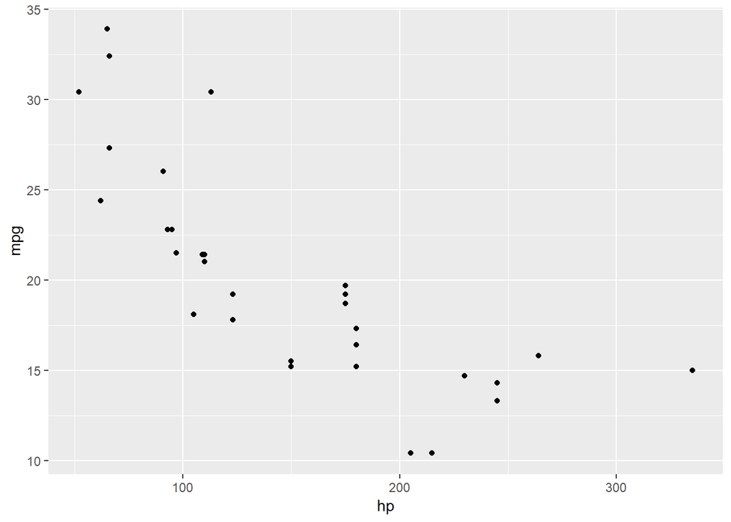

*Fig. 1. Default*

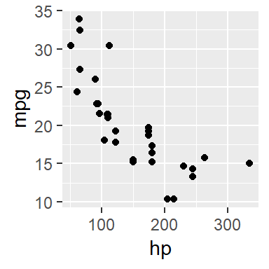

*Fig. 2. Width = 2 by 2 in*

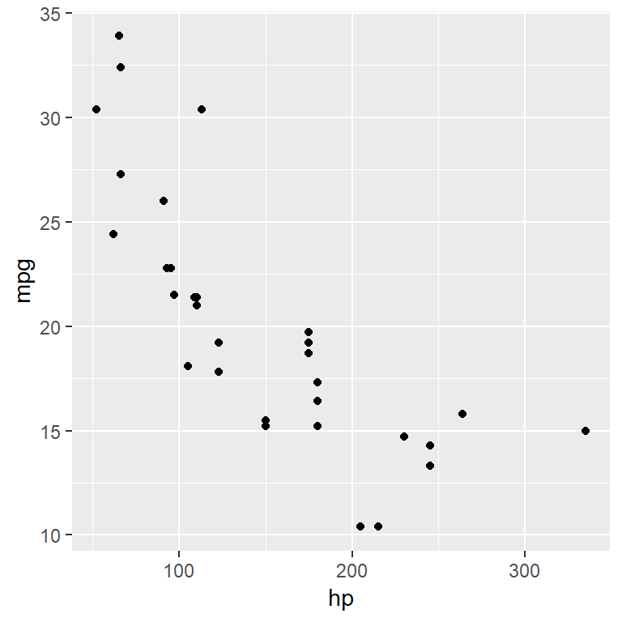

*Fig. 3 Width = 4 x 4 in*

Figure size can be set for the whole document within the YAML header, a global chunk option or within the individual chunk. Note that the default numbers is set to inches.

We can also generate the figures as we would in our R script, or call on figure object within the R script.

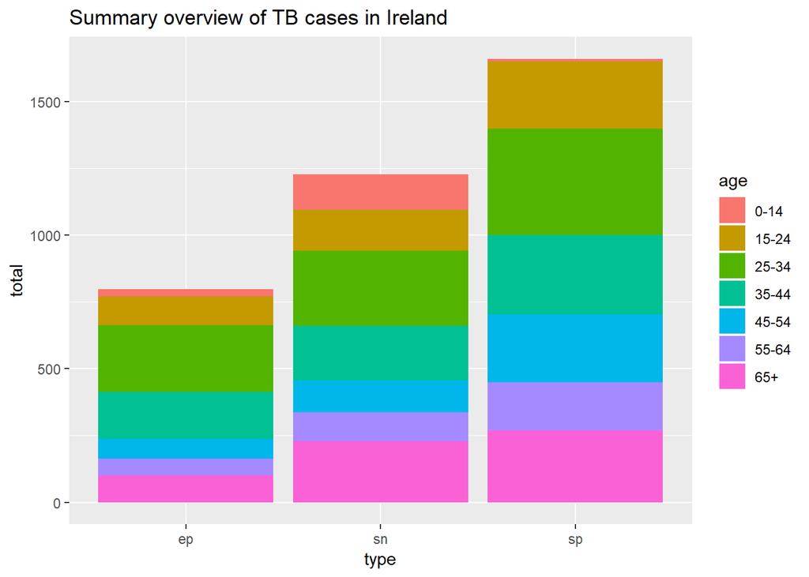

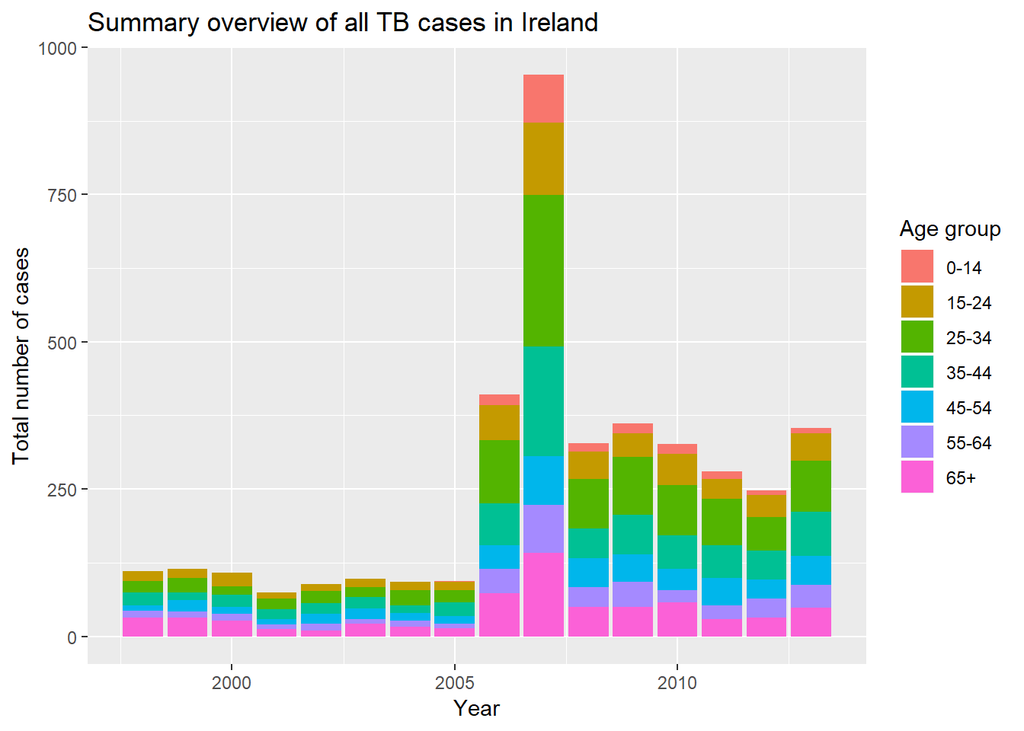

```r
source("scripts/02_plots.R")
# Plot A - early on in the project
who_ire <- who_tb_data %>%
  filter(country == "Ireland" & type != "rel") %>%

# Basic barplot with data by age shown
ggplot() +
  geom_bar(mapping = aes(x = type, y = total, fill = age),
           stat = "identity") +
  labs(title = "Summary overview of TB cases in Ireland")

who_ire
```

Personally, I prefer this second option as the document is less cluttered and changes are confined to the scripts, but you can also call on the image you stored in your plots folder.

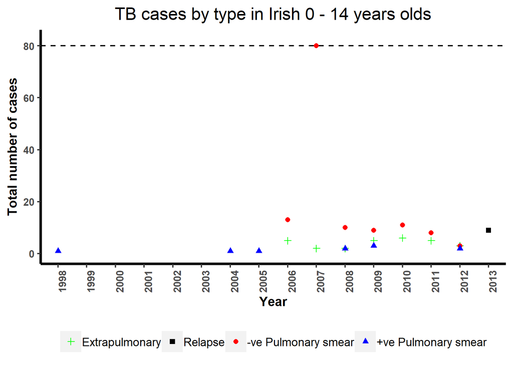

Here’s one I made earlier.

## Caching

Normally each knit of a document starts from a clean slate. This great for reproducibility, but painful if some computations take a long time to run. You can avoid this by setting `cached = TRUE`. This will save the output of the chunk to a named file on disk. On subsequent runs knitr will check to see if the code has changed, and if it hasn’t, will reuse the cached results.

## Bibliographies and citations

Pandoc can automatically generate citations and a bibliography in a number of styles.

This is just as an FYI. We won’t be able to cover it here.

Now, we’ll close this project and move to the example_project folder